# BCB420 - Computational Systems Biology Assignment 1

Joshua Efe

# Basic Information

## Getting the Required packages

```r
## Get required packages
if (!requireNamespace("BiocManager", quietly = TRUE))
    install.packages("BiocManager")
if (!requireNamespace("GEOmetadb", quietly = TRUE))
    BiocManager::install("GEOmetadb")

if (!requireNamespace("BiocManager", quietly = TRUE))
    install.packages("BiocManager")

if (!requireNamespace("edgeR", quietly = TRUE))
    BiocManager::install("edgeR")

if (!requireNamespace("knitr", quietly = TRUE))
    install.packages("knitr")

library("GEOmetadb")
library("edgeR")
library("biomaRt")
library("knitr")
if(!file.exists('GEOmetadb.sqlite')) getSQLiteFile()

file.info('GEOmetadb.sqlite')
```

```
##                        size isdir mode               mtime
## GEOmetadb.sqlite 9746843648 FALSE  644 2020-03-07 23:14:59
##                                ctime               atime  uid  gid uname
## GEOmetadb.sqlite 2020-04-17 21:05:34 2020-04-18 21:54:11 1001 1000  bioc
##                   grname
## GEOmetadb.sqlite rstudio
```

```r
con <- dbConnect(SQLite(),'GEOmetadb.sqlite')
```

## Getting the Data and doing some basic analysis

```r
sfiles = getGEOSuppFiles('GSE72055')
gse <- getGEO("GSE72055",GSEMatrix=FALSE)
kable(data.frame(head(Meta(gse))), format = "html")
```

| contact_address | contact_city | contact_country | contact_email | contact_institute | contact_laboratory |
| --- | --- | --- | --- | --- | --- |
| 1000 E 50th Street | Kansas City | USA | peb@stowers.org | HHMI/Stowers Institute | Baumann |

```r
gset <- getGEO("GSE72055", GSEMatrix =TRUE, getGPL=FALSE)
sfiles = getGEOSuppFiles('GSE72055')

gse <- getGEO("GSE72055",GSEMatrix=FALSE)
## just to see
kable(data.frame(head(Meta(gse))), format = "html")
```

| contact_address | contact_city | contact_country | contact_email | contact_institute | contact_laboratory |
| --- | --- | --- | --- | --- | --- |
| 1000 E 50th Street | Kansas City | USA | peb@stowers.org | HHMI/Stowers Institute | Baumann |

```r
## information
current_gpl <- names(GPLList(gse))[1]
current_gpl_info <- Meta(getGEO(current_gpl))
current_gpl_info$title
```

```
## [1] "Illumina HiSeq 2500 (Homo sapiens)"
```

```r
current_gpl_info$last_update_date
```

```
## [1] "Mar 27 2019"
```

```r
current_gpl_info$organism
```

```
## [1] "Homo sapiens"
```

```r
fnames = rownames(sfiles)
tel_refd1 =read.delim(fnames[1],header=TRUE,
                       check.names = FALSE)

tel_expd = read.delim(fnames[1],header=FALSE,
                       check.names = FALSE)
## had to make header false because the ids didn't have a header so ahd to add names manually
tel_expd2 = tel_expd[2:60107,1:7]
tel_exp = data.frame(tel_expd[2:60107,1], tel_refd1[,1:6])
names(tel_exp) = c("ID","dmso12_1","dmso12_2", "dmso12_3","iso12_1","iso12_2","iso12_3")
kable(tel_exp[1:15,1:7], format = "html")
```

|  | ID | dmso12_1 | dmso12_2 | dmso12_3 | iso12_1 | iso12_2 | iso12_3 |
| --- | --- | --- | --- | --- | --- | --- | --- |
| ENSG00000000003 | ENSG00000000003 | 2228 | 2270 | 2259 | 1361 | 1512 | 1704 |
| ENSG00000000005 | ENSG00000000005 | 0 | 0 | 0 | 0 | 0 | 2 |
| ENSG00000000419 | ENSG00000000419 | 3200 | 3091 | 3126 | 1413 | 1611 | 1914 |
| ENSG00000000457 | ENSG00000000457 | 506 | 528 | 575 | 105 | 106 | 119 |
| ENSG00000000460 | ENSG00000000460 | 2182 | 2093 | 2238 | 919 | 1065 | 1242 |
| ENSG00000000938 | ENSG00000000938 | 1 | 0 | 0 | 2 | 3 | 2 |
| ENSG00000000971 | ENSG00000000971 | 8000 | 7749 | 7981 | 5293 | 5896 | 6576 |
| ENSG00000001036 | ENSG00000001036 | 4939 | 4736 | 4821 | 3747 | 4148 | 4704 |
| ENSG00000001084 | ENSG00000001084 | 3418 | 3099 | 3255 | 1110 | 1110 | 1207 |
| ENSG00000001167 | ENSG00000001167 | 1000 | 958 | 1035 | 199 | 207 | 248 |
| ENSG00000001460 | ENSG00000001460 | 216 | 192 | 191 | 85 | 98 | 91 |
| ENSG00000001461 | ENSG00000001461 | 1614 | 1648 | 1642 | 563 | 549 | 662 |
| ENSG00000001497 | ENSG00000001497 | 6869 | 6320 | 6659 | 5333 | 5526 | 6277 |
| ENSG00000001561 | ENSG00000001561 | 0 | 0 | 0 | 1 | 0 | 1 |
| ENSG00000001617 | ENSG00000001617 | 1843 | 1748 | 1818 | 700 | 863 | 930 |

```r
dim(tel_exp)
```

```
## [1] 60106     7
```

```r
## 60106
```

## Extracting the samples from the data

```r
samples <- data.frame(lapply(colnames(tel_exp)[2:7],
                             FUN=function(x){unlist(strsplit(x, split = "_"))[c(1,2)]}))
colnames(samples) <- colnames(tel_exp)[2:7]
rownames(samples) <- c("treatment","repID")
samples <- data.frame(t(samples))

summarized_gene_counts <- sort(table(tel_exp$ID),decreasing = TRUE)
kable(summarized_gene_counts[which(summarized_gene_counts>1)[1:7]], format="html")
```

| Var1 | Freq |
| --- | --- |
| NA | NA |
| NA | NA |
| NA | NA |
| NA | NA |
| NA | NA |
| NA | NA |
| NA | NA |

```r
## translate out counts into counts per million using the edgeR package function cpm
cpms = cpm(tel_exp[,2:7])
rownames(cpms) <- tel_exp[,1]
## get rid of low counts
keep = rowSums(cpms >1) >=3
tel_exp_filtered = tel_exp[keep,]


dim(tel_exp_filtered)
```

```
## [1] 15082     7
```

Here it shows that we do not have repeated genes

```r
summarized_gene_counts_filtered <- sort(table(tel_exp_filtered$ID),decreasing = TRUE)
```

#Begin Analysis

## Create a Box Plot for Non-normalized data

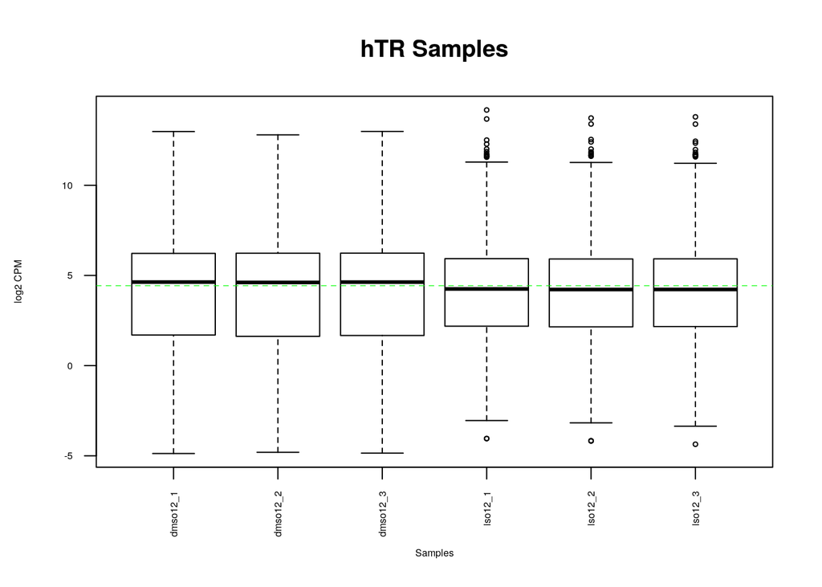

```r
data2plot <- log2(cpm(tel_exp_filtered[,2:7]))
boxplot(data2plot, xlab = "Samples", ylab = "log2 CPM",
        las = 2, cex = 0.5, cex.lab = 0.5,
        cex.axis = 0.5, main = "hTR Samples")

abline(h = median(apply(data2plot, 2, median)), col = "green", lwd = 0.6, lty = "dashed")
```

## Desnsity distribtion for Non-Normalized Data

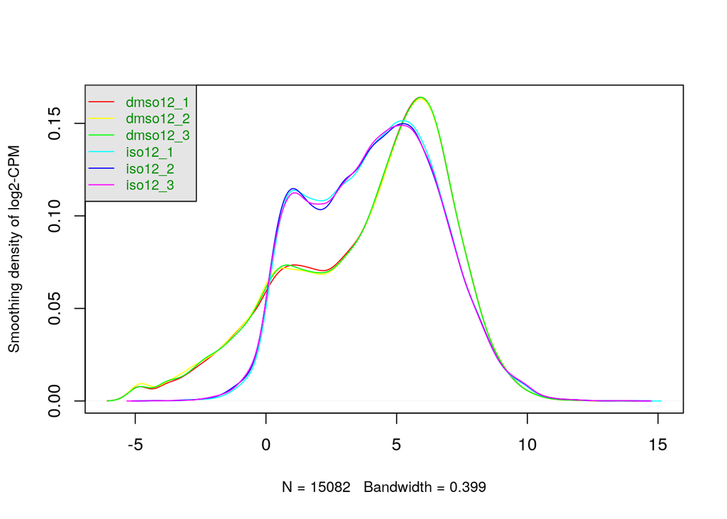

```r
## Distirbution of our data - Density plot
## _________________________________________

counts_density <- apply(log2(cpm(tel_exp_filtered[,2:7])), 2, density)

## calculate limits
xlim <- 0; ylim <- 0
for (i in 1:length(counts_density)) {
    xlim <- range(c(xlim, counts_density[[i]]$x));
    ylim <- range(c(ylim, counts_density[[i]]$y))
}

cols <- rainbow(length(counts_density))
ltys <- rep(1, length(counts_density))

## plot the desnity to inizalize
plot(counts_density[[1]], xlim=xlim, ylim=ylim, type = "n",
     ylab = "Smoothing density of log2-CPM", main="", cex.lab = 0.85)

## plot each line
for(i in 1:length(counts_density)) lines(counts_density[[i]], col=cols[i], lty=ltys[i])

## create legened slide 39
## Changed the size so it fit in the graph
legend("topleft", colnames(data2plot),
       col=cols, lty=ltys, cex=0.8,
       border = "blue", text.col = "green4",
       merge =TRUE, bg = "gray90")
```

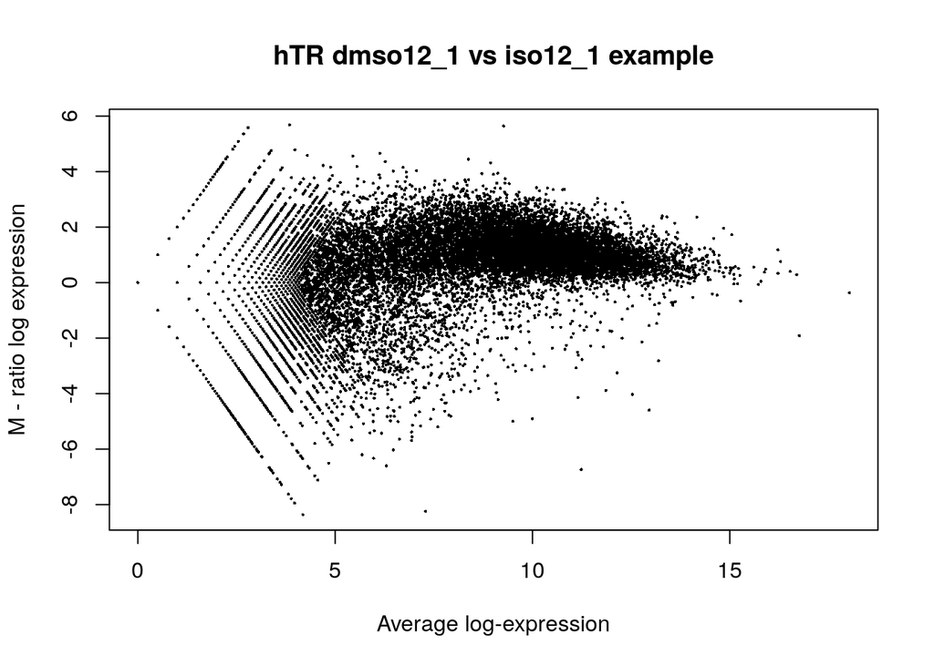

```r
## M vs A
plotMA(log2(tel_exp[,c(2,5)]), ylab="M - ratio log expression", main="hTR dmso12_1 vs iso12_1 example")
```

## Apply TMM to our data

```r
filtered_data_matrix <- as.matrix(tel_exp_filtered[,2:7])
rownames(filtered_data_matrix) <- tel_exp_filtered$ID
d = DGEList(counts=filtered_data_matrix, group=samples$treatment)

d = calcNormFactors(d)

normalized_counts <- cpm(d)
dim(normalized_counts)
```

```
## [1] 15082     6
```

```r
data3plot <- log2(cpm(normalized_counts))
```

## Graphing the normalized data

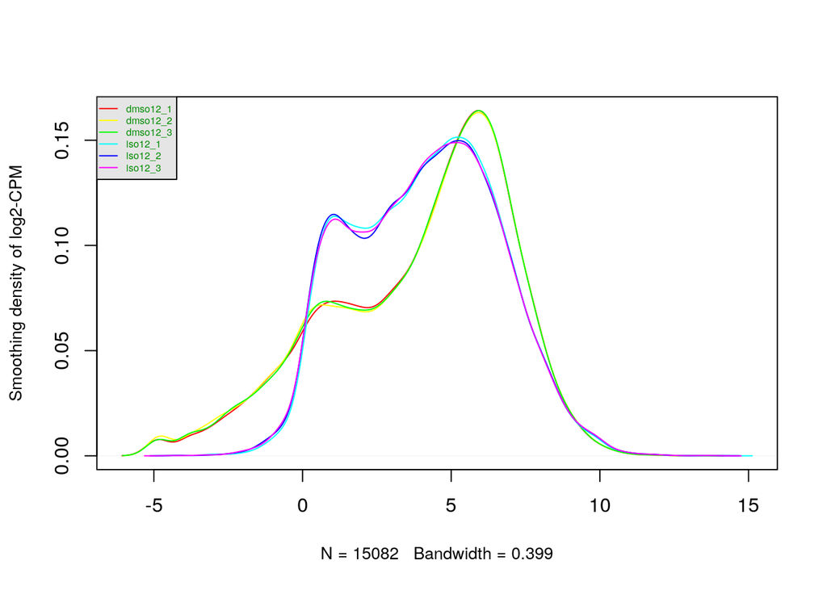

```r
## Graphing the normalized data

counts_density2 <- apply(log2(cpm(normalized_counts[,1:6])), 2, density)

## calculate limits
xlim <- 0; ylim <- 0
for (i in 1:length(counts_density2)) {
    xlim <- range(c(xlim, counts_density2[[i]]$x));
    ylim <- range(c(ylim, counts_density2[[i]]$y))
}

cols <- rainbow(length(counts_density2))
ltys <- rep(1, length(counts_density2))

## plot the desnity to inizalize
plot(counts_density2[[1]], xlim=xlim, ylim=ylim, type = "n",
     ylab = "Smoothing density of log2-CPM", main="", cex.lab = 0.85)

## plot each line
for(i in 1:length(counts_density2)) lines(counts_density2[[i]], col=cols[i], lty=ltys[i])

## create legened slide 39
## Changed the size so it fit in the graph
legend("topleft", colnames(data2plot),
       col=cols, lty=ltys, cex=0.5,
       border = "blue", text.col = "green4",
       merge =TRUE, bg = "gray90")
```

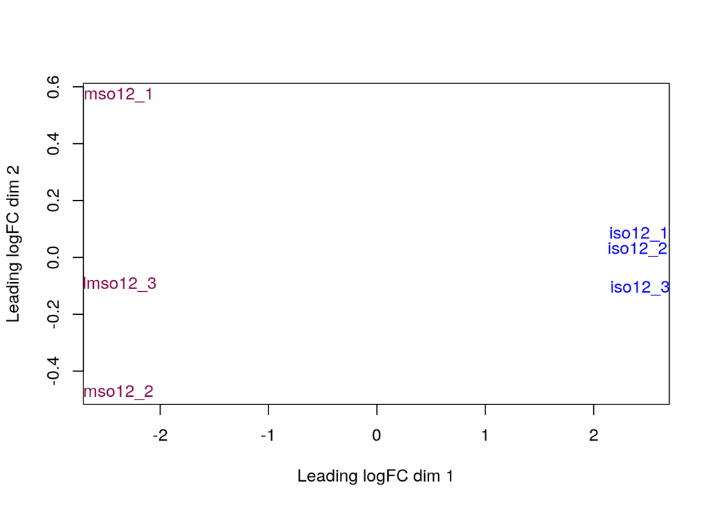

```r
## MDS plot to represent seperation

plotMDS(d, labels=rownames(samples),
        col = c("deeppink4","blue","gold4","coral4", "cyan3")[factor(samples$treatment)])
```

The biological coeffient of variation (BVC) of our data to see how much it varies

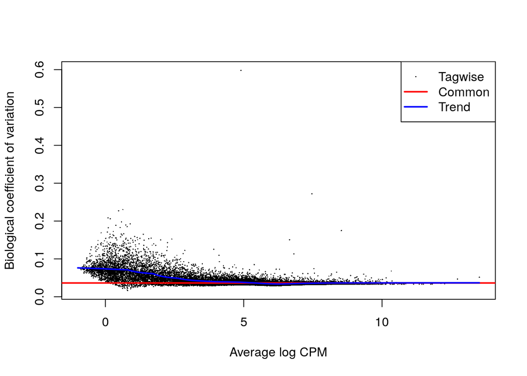

```r
model_design <- model.matrix(~samples$repID + samples$treatment+0)
d <- estimateDisp(d, model_design)
plotBCV(d,col.tagwise = "black",col.common = "red")
```

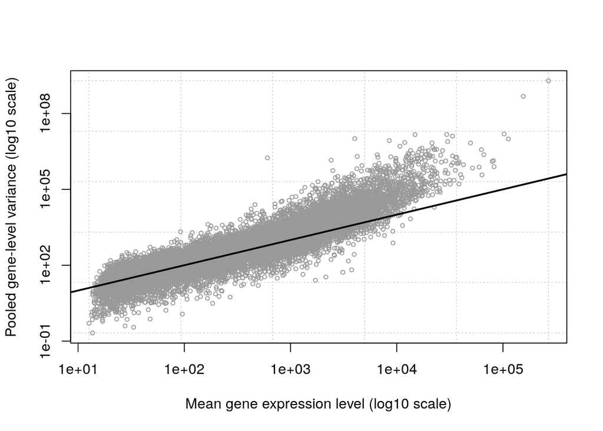

```r
plotMeanVar(d, show.raw.vars = TRUE,
            show.tagwise.vars=FALSE, NBline=FALSE,
            show.ave.raw.vars = FALSE,show.binned.common.disp.vars = FALSE)
```

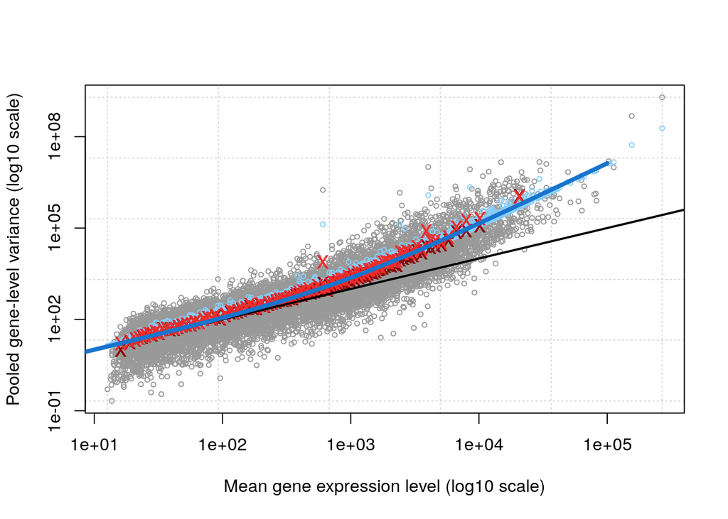

```r
## Create a visual representation of the mean-variance relationship
plotMeanVar(d, show.raw.vars = TRUE, show.tagwise.vars=TRUE,
            show.ave.raw.vars = TRUE,
            NBline=TRUE,
            show.binned.common.disp.vars = TRUE)
```

Finally we have the Normalized DataSet

```r
NormalizedData <- normalized_counts
NormalizedData <-cbind.data.frame(tel_exp_filtered[,1],NormalizedData, stringsAsFactors = FALSE)
colnames(NormalizedData)[1] <-"genes"
NormalizedData$IDs
```

## Time to Map the essemble IDs to HUGO symbols

```r
library(biomaRt)
listMarts()
```

```
##                biomart               version
## 1 ENSEMBL_MART_ENSEMBL      Ensembl Genes 99
## 2   ENSEMBL_MART_MOUSE      Mouse strains 99
## 3     ENSEMBL_MART_SNP  Ensembl Variation 99
## 4 ENSEMBL_MART_FUNCGEN Ensembl Regulation 99
```

```r
listEnsemblArchives()[1:10,]
```

```
##              name     date                                url version
## 1  Ensembl GRCh37 Feb 2014          http://grch37.ensembl.org  GRCh37
## 2      Ensembl 99 Jan 2020 http://jan2020.archive.ensembl.org      99
## 3      Ensembl 98 Sep 2019 http://sep2019.archive.ensembl.org      98
## 4      Ensembl 97 Jul 2019 http://jul2019.archive.ensembl.org      97
## 5      Ensembl 96 Apr 2019 http://apr2019.archive.ensembl.org      96
## 6      Ensembl 95 Jan 2019 http://jan2019.archive.ensembl.org      95
## 7      Ensembl 94 Oct 2018 http://oct2018.archive.ensembl.org      94
## 8      Ensembl 93 Jul 2018 http://jul2018.archive.ensembl.org      93
## 9      Ensembl 92 Apr 2018 http://apr2018.archive.ensembl.org      92
## 10     Ensembl 91 Dec 2017 http://dec2017.archive.ensembl.org      91
##    current_release
## 1
## 2                *
## 3
## 4
## 5
## 6
## 7
## 8
## 9
## 10
```

```r
ensembl <- useMart("ensembl")
datasets <- listDatasets(ensembl)
kable(head(datasets),format = "html")
```

| dataset | description | version |
| --- | --- | --- |
| acalliptera_gene_ensembl | Eastern happy genes (fAstCal1.2) | fAstCal1.2 |
| acarolinensis_gene_ensembl | Anole lizard genes (AnoCar2.0) | AnoCar2.0 |
| acchrysaetos_gene_ensembl | Golden eagle genes (bAquChr1.2) | bAquChr1.2 |
| acitrinellus_gene_ensembl | Midas cichlid genes (Midas_v5) | Midas_v5 |
| amelanoleuca_gene_ensembl | Panda genes (ailMel1) | ailMel1 |
| amexicanus_gene_ensembl | Mexican tetra genes (Astyanax_mexicanus-2.0) | Astyanax_mexicanus-2.0 |

```r
kable(head(datasets[grep(datasets$dataset,pattern = "sapiens"),]),format = "html")
```

|  | dataset | description | version |
| --- | --- | --- | --- |
| 78 | hsapiens_gene_ensembl | Human genes (GRCh38.p13) | GRCh38.p13 |

```r
ensembl = useDataset("hsapiens_gene_ensembl",mart=ensembl)
help(getBM)
dim(listFilters(ensembl))
```

```
## [1] 434   2
```

```r
kable(listFilters(ensembl)[1:10,1:2], type="html")
```

| name | description |
| --- | --- |
| chromosome_name | Chromosome/scaffold name |
| start | Start |
| end | End |
| band_start | Band Start |
| band_end | Band End |
| marker_start | Marker Start |
| marker_end | Marker End |
| encode_region | Encode region |
| strand | Strand |
| chromosomal_region | e.g. 1:100:10000:-1, 1:100000:200000:1 |

```r
biomart_human_filters <- listFilters(ensembl)



conversion_stash <- "tel_exp_conversion.rds"
if(file.exists(conversion_stash)){
  tel_exp_conversion <- readRDS(conversion_stash)
} else {
  tel_exp_conversion <- getBM(attributes = c("ensembl_gene_id","hgnc_symbol"),
                            filters = c("ensembl_gene_id"),
                            values = tel_exp_filtered$ID,
                            mart = ensembl)
  saveRDS(tel_exp_conversion, conversion_stash)
}

nrow(normalized_counts) - nrow(tel_exp_conversion)
```

```
## [1] 181
```

```r
## Merge new IDS
normalized_counts_annot <- merge(tel_exp_conversion,normalized_counts,by.x = 1, by.y = 0, all.y=TRUE)
kable(normalized_counts_annot[1:5,1:5],type = "html")
```

| ensembl_gene_id | hgnc_symbol | dmso12_1 | dmso12_2 | dmso12_3 |
| --- | --- | --- | --- | --- |
| ENSG00000000003 | TSPAN6 | 73.30631 | 78.92493 | 75.65851 |
| ENSG00000000419 | DPM1 | 105.28733 | 107.47002 | 104.69611 |
| ENSG00000000457 | SCYL3 | 16.64856 | 18.35787 | 19.25792 |
| ENSG00000000460 | C1orf112 | 71.79280 | 72.77087 | 74.95518 |
| ENSG00000000971 | CFH | 263.21834 | 269.42258 | 267.29995 |

```r
ensembl_id_missing_gene <- normalized_counts_annot$ensembl_gene_id[
  which(is.na(normalized_counts_annot$hgnc_symbol))]
length(ensembl_id_missing_gene)
```

```
## [1] 181
```

```r
normalized_counts_annot <- subset(normalized_counts_annot, is.na(normalized_counts_annot$hgnc_symbol) == FALSE)
NormalizedData <- normalized_counts_annot
#citation("GEOmetadb")
```

# Questions and answers

Q: What are the control and test conditions of the dataset? The control conditon are the cells that were treated with DMSO. There were a couple test conditions but in here I chose to focus on isoginkgetin treated cells.

Q:Why is the dataset of interest to you? I was intrested in the magnament of telomeres as they are important in understanding aging, cell health, cancer, the biological immortality seen in the species of jellyfish Turritopsis dohrnii also known as the immortal jellyfish and to better understand animal telomarse regulation

Q:Were there expression values that were not unique for specific genes? How did you handle these? No

Q:Were there expression values that could not be mapped to current HUGO symbols? Yes, there were 181, I removed them here but added them later in A2 and A3

The coverage is pretty good I decied to only look at the test case for the cells trated with isoginkgetin. There are 3 replicates for both this test case and for the control case.

# References

(Tseng et al. 2015)

Tseng, Chi-Kang, Hui-Fang Wang, Allison M. Burns, Morgan R. Schroeder, Martina Gaspari, and Peter Baumann. 2015. “Human Telomerase Rna Processing and Quality Control.” *Cell Reports* 13 (10): 2232–43. https://doi.org/10.1016/j.celrep.2015.10.075.